# Weekly Energy Charts

May 13, 2022

[Sign up here to get on our email list](https://docs.google.com/forms/d/e/1FAIpQLSckqeGjUvIlhveVyjmkXe913tzQRLANqPNQzEZTUQD2hQxH8g/viewform?usp=pp_url)

# Featured Stories

## Record Tree Losses In 2021

#### Keshinee Moonian

The number of trees destroyed in northern parts of Russia, Canada and Alaska in 2021 was up 30% from 2020. Climate change is considered one of the main drivers of this phenomenon, with hotter and drier conditions causing more wildfires and more damage from insects.

Tree losses also continued at high levels in tropical areas, with the non-fire related destruction increasing by 9% overall. In some main states in the western Amazon area, losses were as high as 25%.

Some researchers fear that the Brazilian rainforest “may be approaching a tipping point when it emits more carbon than it stores.” This will hinder its role in limiting the rise in global temperatures this century.

On a more positive note, Indonesia curbed tree losses for the fifth year in a row. Indonesian initiatives which have proved successful so far include a permanent moratorium on converting primary forest and peatland for palm oil, and a commitment in their national climate plan to reduce emissions from forests.

Countries committed to “halt and reverse forest loss by 2030” at COP26, which will require considerable and rapid action in many countries. Wildfires are linked to the hotter, drier conditions that climate change is bringing, and this will compound the local effects of deforestation.

[Climate change: Record tree losses in 2021 in northern regions](https://www.bbc.com/news/science-environment-61248596)

## Global Renewable Growth Continues

#### [Yousaff Habib](https://www.linkedin.com/in/yousaff-habib-6684891a5/)

Renewable energy growth has accelerated for nearly a decade, and this trend will only be amplified by current events, a new [IEA report](https://www.iea.org/news/renewable-power-is-set-to-break-another-global-record-in-2022-despite-headwinds-from-higher-costs-and-supply-chain-bottlenecks) suggests. Despite supply chain issues, construction delays, and high prices stemming from the COVID-19 pandemic, [renewable net capacity additions are still rising](https://www.iea.org/data-and-statistics/charts/renewable-net-capacity-additions-2019-2021). The waning COVID-19 pandemic, the Russia-Ukraine conflict, and continued concerns about climate change following the recent [IPCC report.](https://www.ipcc.ch/report/ar6/wg2/downloads/report/IPCC_AR6_WGII_FinalDraft_TechnicalSummary.pdf) continue to drive markets for alternatives to natural gas and other fossil fuels and boost the prospects for renewables.

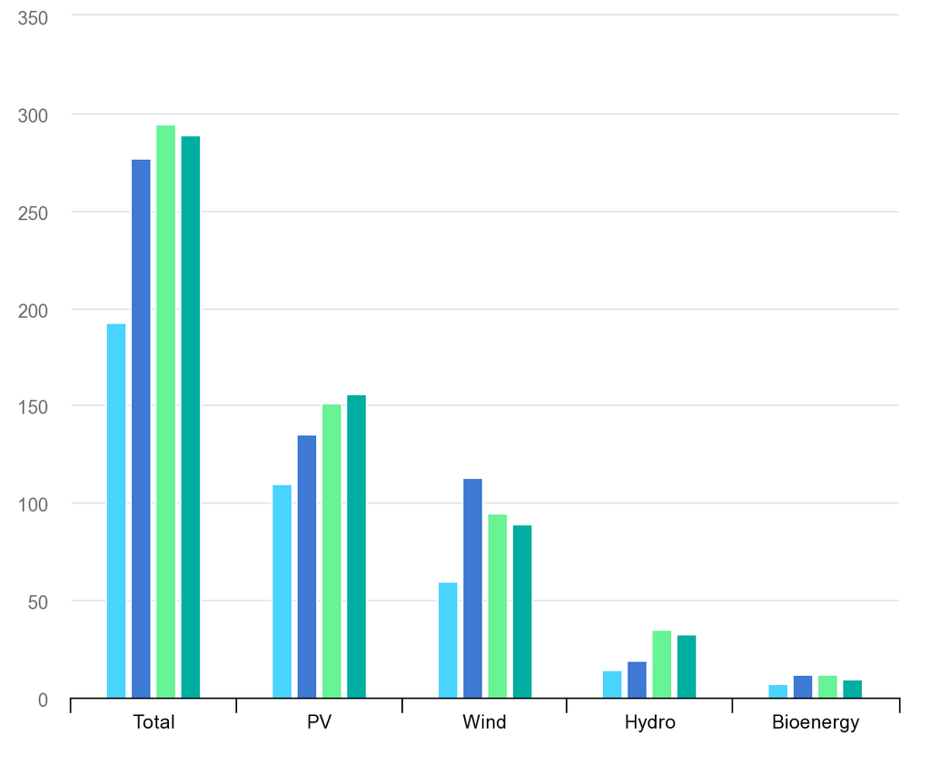

The European Commission has launched a renewed push for the expansion of renewable and other secure sources of energy. The [outline](https://eur-lex.europa.eu/legal-content/EN/TXT/?uri=COM%3A2022%3A108%3AFIN) mentions importing higher levels of hydrogen, reducing the use of fossil fuels, increasing renewables, and addressing energy infrastructure bottlenecks.

For more details, see the [IEA May 2022 Report on renewable electricity](https://www.iea.org/reports/renewable-energy-market-update-may-2022/renewable-electricity).

## A Reality Check on CCUS and the Oil Sands

#### Erica Beattie

There is a lot of talk these days about how Canada is in a strong position to ensure global energy security, but this is not without its challenges. The main issue being how to accomplish this without sacrificing our climate goals. A new report from [RBC](https://thoughtleadership.rbc.com/the-new-climate-bargain-how-canada-can-manage-energy-environmental-security/) shows just how hard reconciling these two objectives might be.

In just one example, RBC’s study shows that deployment of carbon capture and storage (CCUS) could roughly double the break-even cost for oil sands projects.

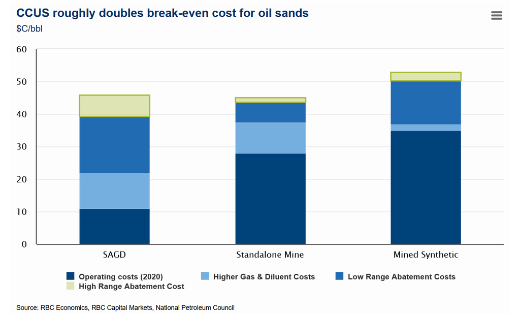

Carbon capture and storage (CCUS) could roughly double the break-even cost for oil sands

If that doesn’t stop you in your tracks this week, I don’t know what will.

## Big Day for Renewable Energy in California

#### Debosree Mukherjee

April 30th, 2022 was a big day for clean energy advocates in California as the state reached a major milestone. [California was almost 100% powered by renewables for the first time in history.](https://www.abc10.com/article/weather/california-renewable-energy/103-98fa3c6b-7763-4e35-b4f0-6162c0c0774a) Solar and wind energy supplied 99.87% of the state’s electricity demand for two minutes at around 2:50 pm. According to the California Independent System Operator (CAISO) tracker, energy demand was 18,672 megawatts on April 30th at 2:45 pm, so we’re not talking about a small-volume market!

California’s main source of renewable energy is solar followed by wind, geothermal, biofuels, and hydro. California, the world’s fifth largest economy, is the largest renewable energy producer in US and [is currently aiming to achieve 100% clean electricity by 2045.](https://www.independent.co.uk/climate-change/news/california-clean-energy-solar-power-b2070040.html) Although the new record was set only for a brief moment, it is certainly significant. In recent years, around 60% of the state’s total electricity generation from renewable and zero-carbon sources.

## EIA’s Short Term Energy Outlook

#### Andrew Leach

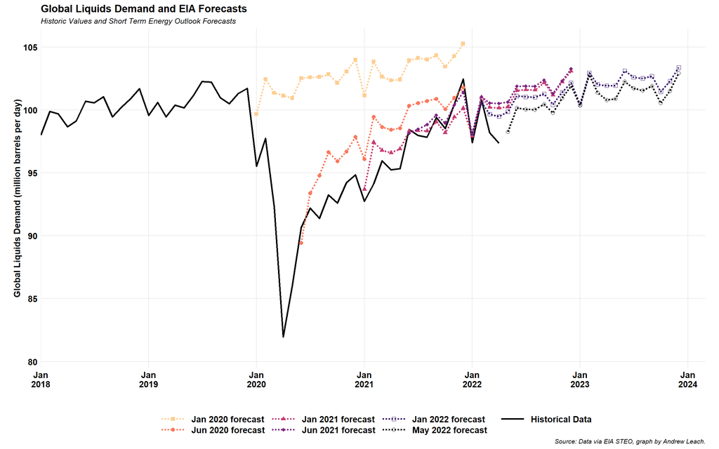

The US [Energy Information Administration (EIA)](https://www.eia.gov/) releases a monthly [short-term energy outlook](https://www.eia.gov/outlooks/steo/) with outlooks for most energy commodities. I maintain an updated graph pack for these outlooks at my [STEO data page](https://leachandrew.github.io/EIA-STEO/). I hope you enjoy it.

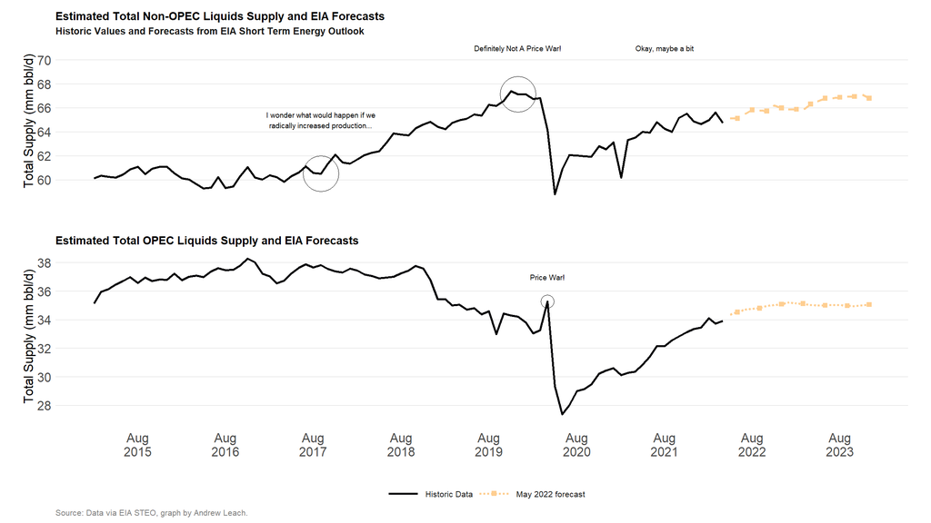

# Oil

## Weekly Crude Prices

### Feature Crude

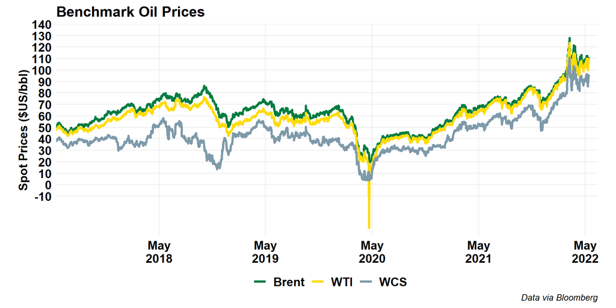

### Alberta Crude

[figure not shown]

### US Crude

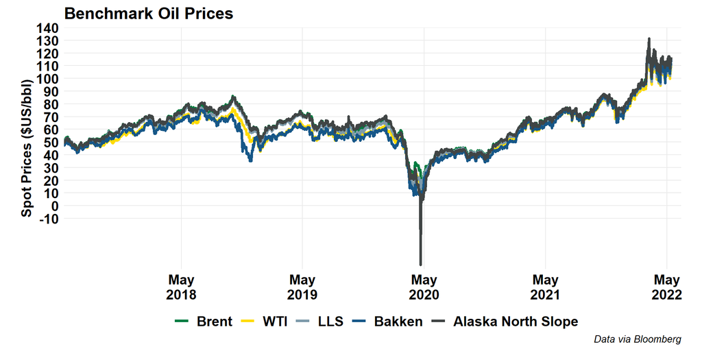

### Global Crude

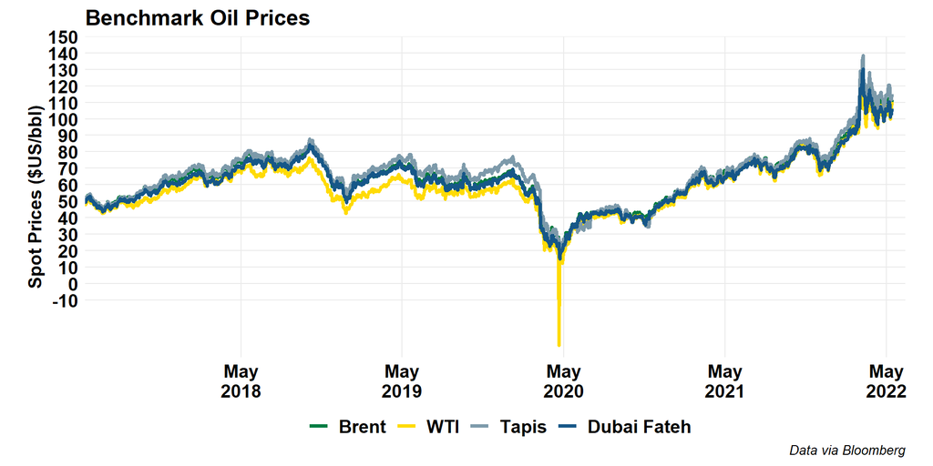

## Oil Price Differentials

### Brent-WTI

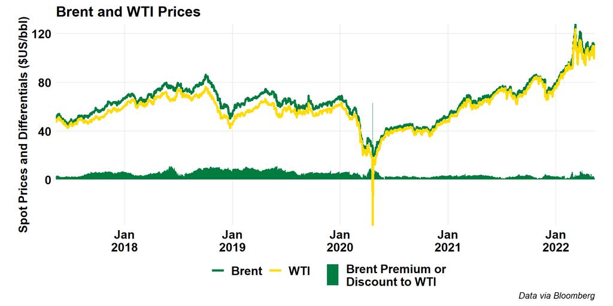

### WTI-WCS

[figure not shown]

### Maya-WCS

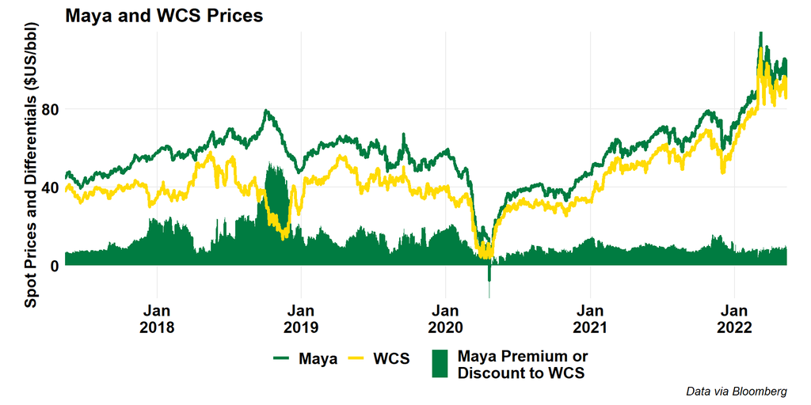

### WTI Cushing vs MEH

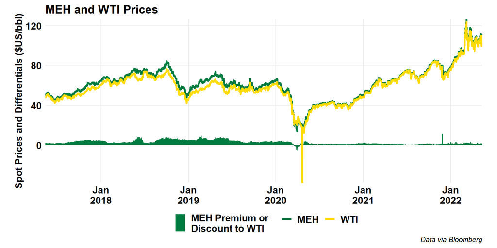

## EIA Petroleum Status Report

### Crude Oil Production

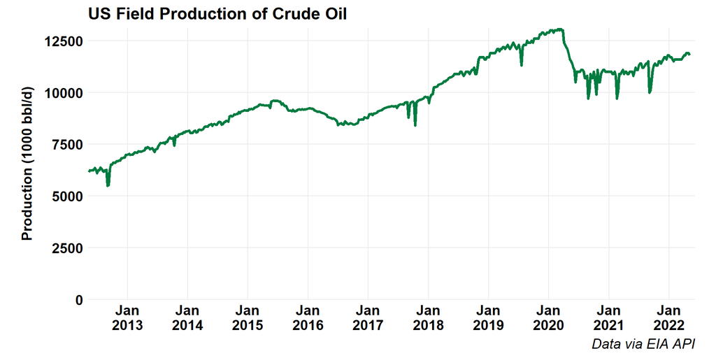

### Net Crude Oil Imports

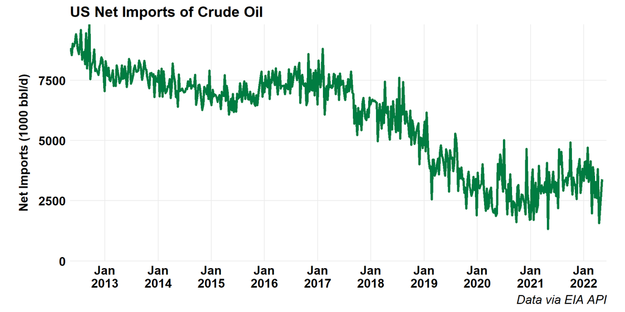

### Net Imports of Crude Oil and Products

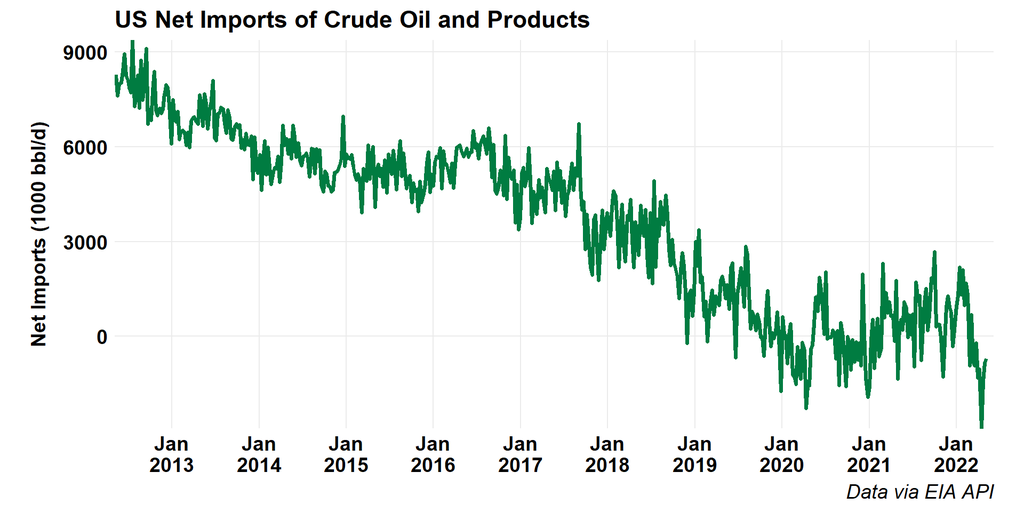

### Crude Inventories

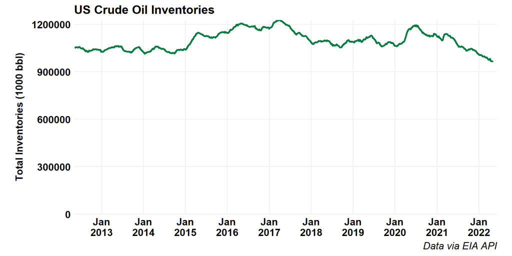

## Forward Curves

### WTI

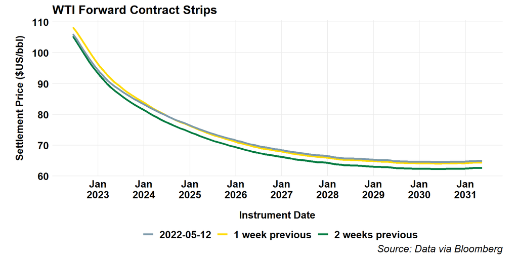

### Brent

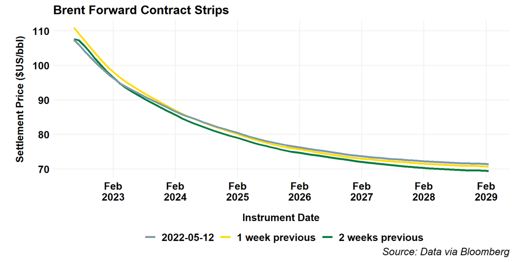

## Canadian Crude Exports

### Crude by Rail Exports

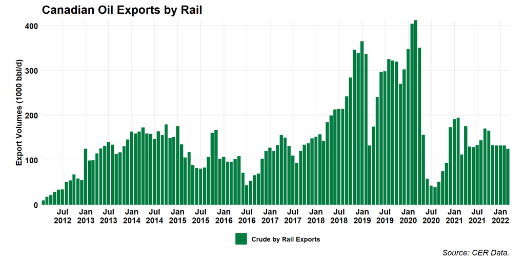

# Refined Products

## Canadian Gasoline Prices

### Map

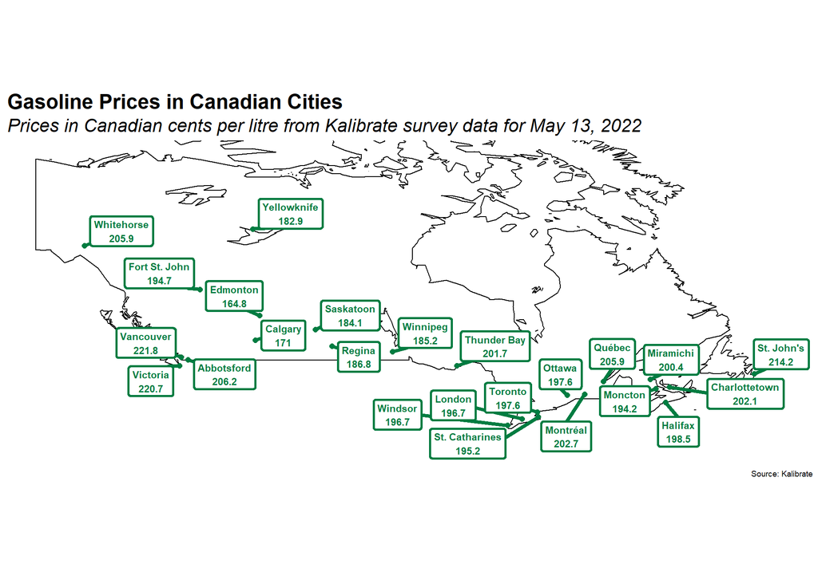

### Historic Gasoline Prices

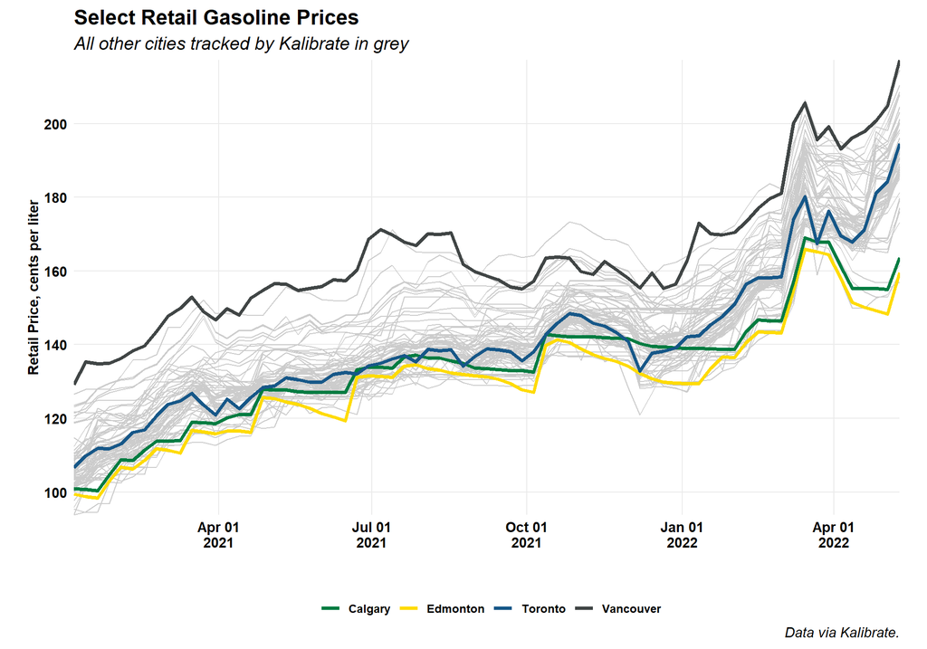

### Historic Diesel Prices

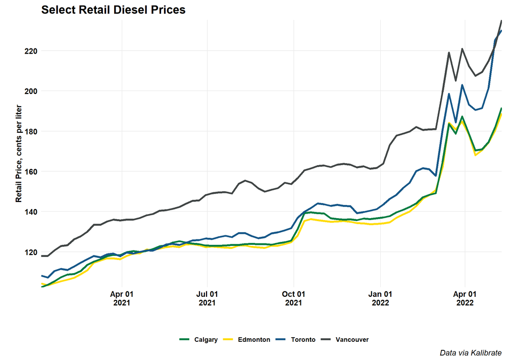

## Canadian Refinery Runs

### Canadian Refinery Runs

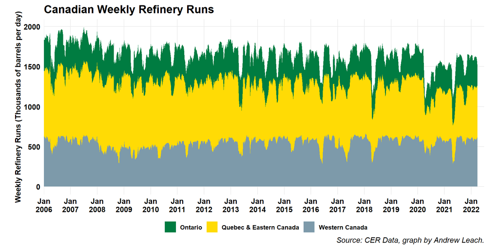

### Western Canada Refinery Runs

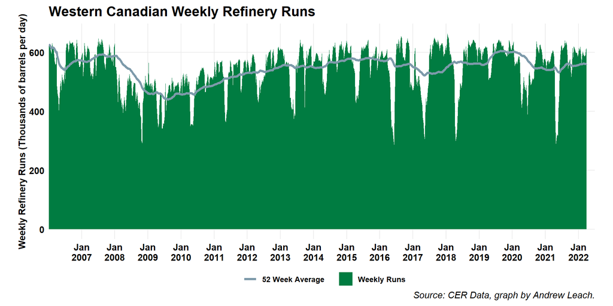

# Natural Gas

## Natural Gas Market Summary

### Feature Gas

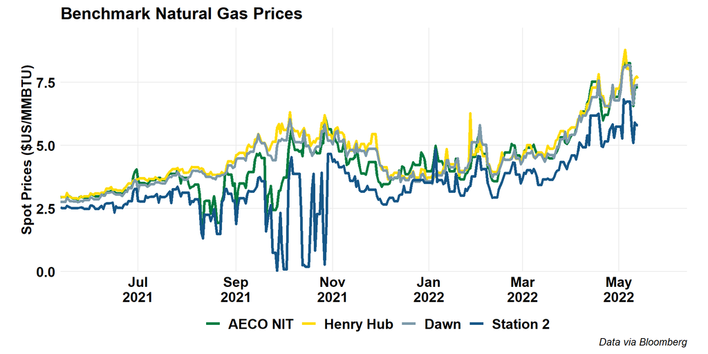

### Global Gas

[figure not shown]

### North American Gas Hubs

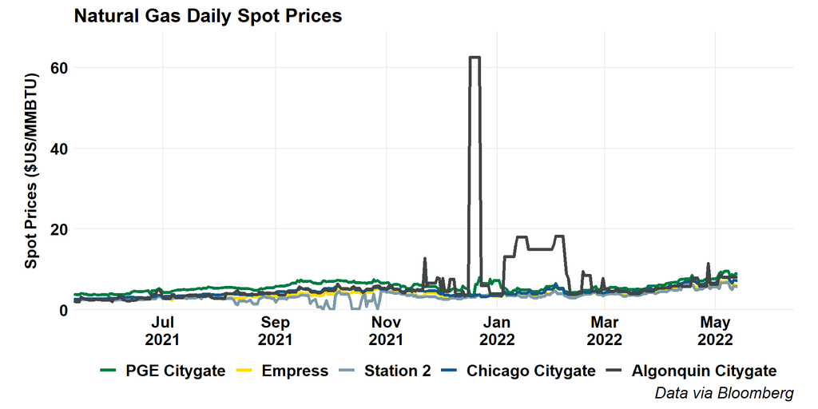

## Forward Prices

### Henry Hub

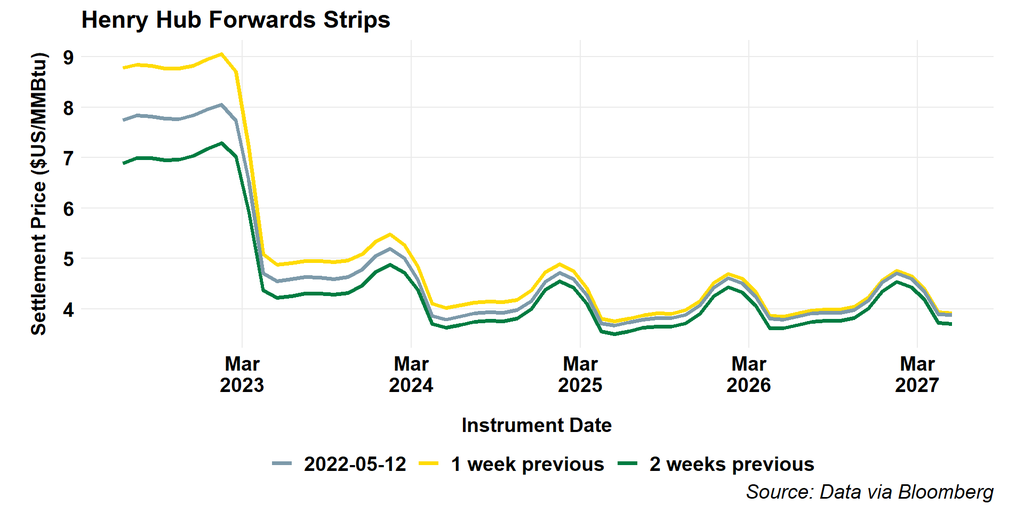

### Alberta (NIT) ($CAD)

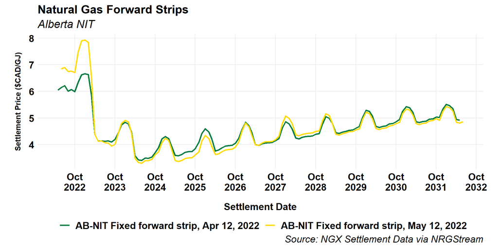

### Alberta (NIT)

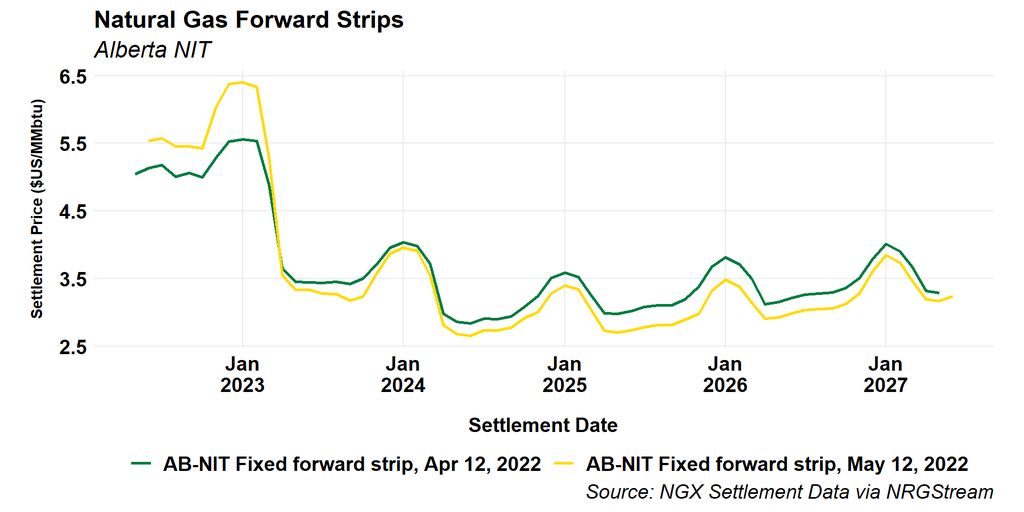